# Homework 2 - SDS

Andrea Conti - Davide Mascolo - Mario Napoli

27 dicembre 2021

### 1. Introductory

Let's define the remaining $\nu$ values: $\nu(AB) = 2, \quad \nu(AC) = 0, \quad \nu(BC) = 2$. Now we can build the table as follows:

| Permutations | A | B | C |
| --- | --- | --- | --- |
| ABC | 0 | 2 | 2 |
| ACB | 0 | 4 | 0 |
| BAC | 2 | 0 | 2 |
| BCA | 2 | 0 | 2 |
| CAB | 0 | 4 | 0 |
| CBA | 2 | 2 | 0 |

From this table we can compute Shapley values: $\psi(A) = \frac{6}{6} = 1, \quad \psi(B) = \frac{12}{6} = 2, \quad \psi(C) = \frac{6}{6} = 1$. We can normalize these values in a way that they sum up to 1, in other words we can divide them by 4 but the interpretation would remain the same: A save 1 hour of work (or 25% of the total savings if we normalize), B 2 hours (or 50% of the total) and C another hour (the remaining 25%).

### 2. Probabilistic

```r
## Utils
library(tseries)
library(igraph)
library(knitr)
```

```r
## Load CharFun
load('char_fun.RData')
```

```r
options(scipen = 999)
```

We separate coalitions in which it is present *j* from those in which *j* is not present.

```r
## Split lists
split_list <- function(j){
  # Input: a specific player
  # Output: a list with all the coalitions in which j is not present
  no_j <- vector(mode = "list", length = 2048-1)
  k <- 1
  for (i in 1:12){
      for (c in 1:length(char_fun[[i]])){
        name <- names(char_fun[[i]][c])
        value <- char_fun[[i]][[c]]
        if (!(j %in% as.integer(strsplit(name, '-')[[1]]))){
          no_j[[k]] <- c(name, value)
          k = k + 1
        }
      }
  }
  return(no_j)
}
```

Compute the differences between the values of the coalitions without the player *j* and the coalitions with the player *j*.

```r
compute_diff <- function(j){
  # Input: a specific player
  # Output: list in which are stored the difference: C U {j} - C
  no_j <- split_list(j)
  diff_list <-c()
  for (i in 1:length((no_j))){
    coal <- no_j[[i]][1]
    val_coal <- as.integer(no_j[[i]][2])
    # Just elaboration to obtain the number (players) in coalition C U {j}
    coal2 <- paste(sort(c(as.numeric(unlist(strsplit(coal, split = '-'))), j)), collapse = '-')
    tmp <- strsplit(coal2, split = '-')[[1]]
    val_coal2 <- char_fun[[length(tmp)]][coal2][[1]]
    diff_list <- c(diff_list, val_coal2 - val_coal)
  }
  return(diff_list)
}
```

```r
## Simulation
simul <- function(j){
  # Input: a specific player
  # Output: our estimated Shapley values plus more things useful for later steps:
  #         - max and min of the difference list
  #         - M, our computed simulation size
  alpha <- 0.05
  epsilon <- 0.1

  diff_list <- compute_diff(j)

  M <- ceiling(((max(diff_list) - min(diff_list))^2*log(2/alpha))/(2*(epsilon^2)))
  tot <- 0

  for (i in 1:M){
    n <-sample(diff_list, 1, replace = TRUE)
    tot = tot + n
  }

  return(c(tot / M, max(diff_list), min(diff_list), M))
}
```

We run the simulation for the three selected players and compute the respective confidence intervals.

```r
## Set players
players <- c(2, 3, 5)

df <- data.frame(matrix(0, nrow = 3, ncol = 3))
colnames(df) <- c('LowerBound', 'Value', 'UpperBound')
rownames(df) <- c(players)
i <- 1
for (p in players){
  shap_ret = simul(p)
  shapley_val = shap_ret[1]
  mx <- shap_ret[2]
  mn <- shap_ret[3]
  M <- shap_ret[4]
  eps_alpha <- sqrt(((mx - mn)^2 * log(2/0.05)) / (2*M))
  df$LowerBound[i] <- shapley_val - eps_alpha
  df$Value[i] <- shapley_val
  df$UpperBound[i] <- shapley_val + eps_alpha
  i = i + 1
}
kable(df)
```

|  | LowerBound | Value | UpperBound |
| --- | --- | --- | --- |
| 2 | 6.697495 | 6.797485 | 6.897475 |
| 3 | 5.818037 | 5.918022 | 6.018007 |
| 5 | 2.874096 | 2.974096 | 3.074096 |

We set $\alpha = 0.05$ and $\epsilon = 0.1$. Then, starting from the following formula $\epsilon_\alpha = \sqrt{\frac{(b-a)^2}{2M}\log{(\frac{2}{\alpha})}}$ we reversed it in order to compute $M$, that is the size of the simulation that allows us to reach a $1-\alpha$ confidence interval. After that, we computed the confidence intervals of the Shapley values for each player. Regardless of the value of $M$, we can note that $\epsilon_\alpha$ is almost the same for the three players that we have chosen. This implies that the confidence intervals for the three different players about the same width due to our "$\alpha$-level".

### 3. Statistical

##### List of S&P 500

- AMZN - Customer Discretionary
- MSFT - Informational Technlogy
- BLK - Financials
- CAH - Healt-Care
- VZ - Communication Services
- CVX - Energy
- ECL - Materials
- EIX - Utilitis
- DAL - Industrials
- SYY - Customer Staples

```r
## Load Data Function
load_data <- function(code){
  # Input: a specific code of stock (e.g. Amazon -> AMZN)
  # Output: the historical series of that title

  data <- get.hist.quote(instrument = code,
                         start = '2020-01-01',
                         end = '2021-12-22',
                         quote = c('Open', 'Close'),
                         provider = 'yahoo',
                         drop = TRUE)
  return(data)
}
```

Load data

```r
options("getSymbols.warning4.0"=FALSE)
## AMZN
amz_data <- load_data('AMZN')
## MSFT
msft_data <- load_data('MSFT')
## BR
blk_data  <- load_data('BR')
## CAH
cah_data  <- load_data('CAH')
## VZ
vz_data   <- load_data('VZ')
## CVX
cvx_data  <- load_data('CVX')
## ECL
ecl_data  <- load_data('ECL')
## EIX
eix_data  <- load_data('EIX')
## DAL
dal_data  <- load_data('DAL')
## SYY
syy_data  <- load_data('SYY')
```

Build portfolio

```r
port <- data.frame(matrix(0, nrow(amz_data-1), 10))
names(port) <- c('AMZN', 'MSFT', 'BLK', 'CAH', 'VZ',
                 'CVX', 'ECL', 'EIX', 'DAL', 'SYY')

## Populate Port
for (i in (2:nrow(amz_data))){
  port$AMZN[i-1]<-log(amz_data$Close[[i]]/
                        amz_data$Close[[i-1]])
  port$MSFT[i-1]<-log(msft_data$Close[[i]]/
                      msft_data$Close[[i-1]])
  port$BLK[i-1]<-log(blk_data$Close[[i]]/
                       blk_data$Close[[i-1]])
  port$CAH[i-1]<-log(cah_data$Close[[i]]/
                       cah_data$Close[[i-1]])
  port$VZ[i-1]<-log(vz_data$Close[[i]]/
                       vz_data$Close[[i-1]])
  port$CVX[i-1]<-log(cvx_data$Close[[i]]/
                        cvx_data$Close[[i-1]])
  port$ECL[i-1]<-log(ecl_data$Close[[i]]/
                        ecl_data$Close[[i-1]])
  port$EIX[i-1]<-log(eix_data$Close[[i]]/
                        eix_data$Close[[i-1]])
  port$DAL[i-1]<-log(dal_data$Close[[i]]/
                        dal_data$Close[[i-1]])
  port$SYY[i-1]<-log(syy_data$Close[[i]]/
                        syy_data$Close[[i-1]])
}

## View
kable(head(port))
```

| AMZN | MSFT | BLK | CAH | VZ | CVX | ECL | EIX | DAL | SYY |
| --- | --- | --- | --- | --- | --- | --- | --- | --- | --- |
| -0.0122133 | -0.0125299 | 0.0008075 | -0.0146810 | -0.0107040 | -0.0034648 | -0.0047951 | 0.0053634 | -0.0167382 | -0.0036685 |
| 0.0147759 | 0.0025815 | 0.0090004 | 0.0082720 | -0.0021547 | -0.0033939 | -0.0085405 | 0.0046695 | -0.0069133 | -0.0013049 |
| 0.0020894 | -0.0091596 | -0.0035262 | 0.0004018 | -0.0111789 | -0.0128517 | -0.0012794 | 0.0096696 | -0.0008675 | -0.0081049 |
| -0.0078393 | 0.0158029 | 0.0064021 | 0.0054081 | 0.0018440 | -0.0114886 | 0.0003733 | -0.0015832 | 0.0212956 | 0.0115416 |
| 0.0047878 | 0.0124156 | 0.0216216 | 0.0047828 | -0.0145077 | -0.0016155 | 0.0132424 | 0.0052673 | 0.0018674 | 0.0011823 |
| -0.0094552 | -0.0046378 | -0.0039893 | 0.0065392 | 0.0023762 | -0.0091473 | -0.0058580 | -0.0084411 | 0.0047378 | 0.0034208 |

```r
## Estimate Correlation Matrix
kable(cor(port), allign = 'cccccccccc')
```

|  | AMZN | MSFT | BLK | CAH | VZ | CVX | ECL | EIX | DAL | SYY |
| --- | --- | --- | --- | --- | --- | --- | --- | --- | --- | --- |
| AMZN | 1.0000000 | 0.6995065 | 0.3449303 | 0.2237681 | 0.2642836 | 0.1856723 | 0.2743749 | 0.2616399 | 0.1183332 | 0.1944775 |
| MSFT | 0.6995065 | 1.0000000 | 0.5919804 | 0.4622477 | 0.4560432 | 0.4746435 | 0.5551238 | 0.4626765 | 0.2781587 | 0.4046860 |
| BLK | 0.3449303 | 0.5919804 | 1.0000000 | 0.5182275 | 0.4573839 | 0.5462833 | 0.6335207 | 0.4960012 | 0.3671207 | 0.3592832 |
| CAH | 0.2237681 | 0.4622477 | 0.5182275 | 1.0000000 | 0.5297572 | 0.5221106 | 0.5218033 | 0.4743590 | 0.3996110 | 0.4234221 |
| VZ | 0.2642836 | 0.4560432 | 0.4573839 | 0.5297572 | 1.0000000 | 0.4614280 | 0.5200294 | 0.5591718 | 0.2793635 | 0.4353010 |
| CVX | 0.1856723 | 0.4746435 | 0.5462833 | 0.5221106 | 0.4614280 | 1.0000000 | 0.6577619 | 0.5771347 | 0.6149195 | 0.6406492 |
| ECL | 0.2743749 | 0.5551238 | 0.6335207 | 0.5218033 | 0.5200294 | 0.6577619 | 1.0000000 | 0.6071047 | 0.5329082 | 0.5774348 |
| EIX | 0.2616399 | 0.4626765 | 0.4960012 | 0.4743590 | 0.5591718 | 0.5771347 | 0.6071047 | 1.0000000 | 0.4313016 | 0.5845748 |
| DAL | 0.1183332 | 0.2781587 | 0.3671207 | 0.3996110 | 0.2793635 | 0.6149195 | 0.5329082 | 0.4313016 | 1.0000000 | 0.6648280 |
| SYY | 0.1944775 | 0.4046860 | 0.3592832 | 0.4234221 | 0.4353010 | 0.6406492 | 0.5774348 | 0.5845748 | 0.6648280 | 1.0000000 |

```r
## List of Companies
companies <- c(names(port))

## Init Graph (Undirected)
net <- make_empty_graph(10, F)

## Vertex names
V(net)$name <- companies

## Colors
colors <- c('gray', 'green', 'blue', 'red')
```

We place an edge only if 0 doesn't belong in the confidence interval and we choose the color of this edge based on the correlation value.

```r
for (i in 1:(length(companies)-1)){
  for (j in (i+1):length(companies)){
    cor_value <- cor.test(port[,i],
                          port[,j])
    conf_int <- cor_value$conf.int
    est_cor  <- cor_value$estimate
    if (!((conf_int[1]<= 0) & (conf_int[2]>=0))){
      if (est_cor <= 0.25)
        col <- colors[1]
      else if (est_cor <= 0.50)
        col <- colors[2]
      else if (est_cor <= 0.75)
        col <- colors[3]
      else
        col <- colors[4]
      net <- add_edges(net, c(companies[i],
                              companies[j]),
                       color = col)
    }
  }
}
```

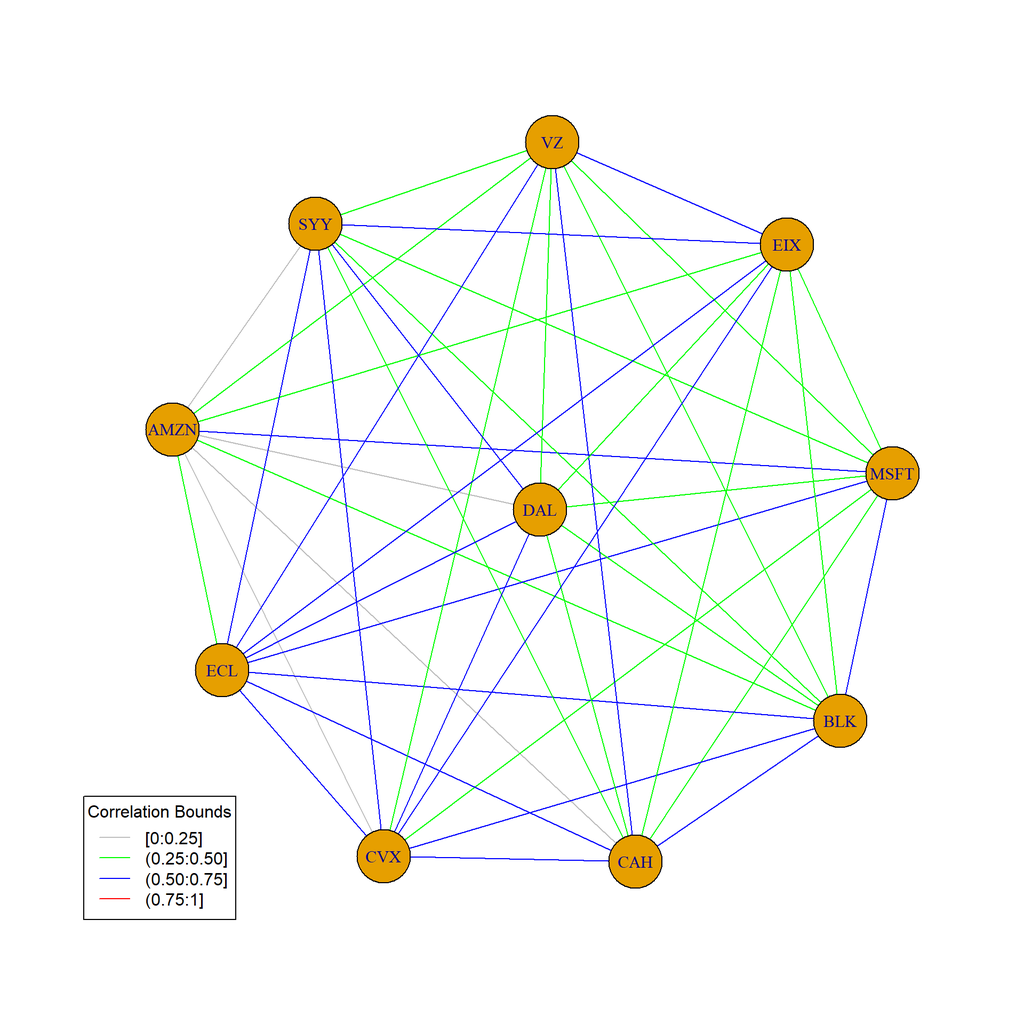

```r
## Plot Graph
plot(net)
legend('bottomleft',
       legend = c('[0:0.25]', '(0.25:0.50]',
                  '(0.50:0.75]', '(0.75:1]'),
       title = 'Correlation Bounds',
       lty = 1,
       col = colors)
```

We choose to pick one company from each *GICS Sector* in order to diversificate our portfolio, this is also an attempt to reduce correlations (e.g. we imagine that Facebook and Google are more co-related than Google and an energy company) between stocks. We also choose a *95% Normal* confidence interval setting $\alpha=0.05$. With this setting no correlation contains 0 within the range and no correlation exceeds the value of 0.75 and this, in our graph, results in a complete graph, despite this we noticed that more than a few stocks are weakly correlated with others and this is the reason why we choose to place edges of different colors.

```r
## Estimate Shapley Values
sv <- rep(0, ncol(port))
sv_hat <- function(X, omega = 0.7){
  for (i in 1:ncol(port)){
    sv[i] <- mean(X[,i]) + sum(cov(X)[,i]) * omega
  }
  return(sv)
}

## Check
shapley <- sv_hat(port)
```

```r
## Bootstrap
B <- 1000
sv_boot <- rep(NA, B)

## Cycle
for (i in 1:B){
  idx       <- sample(1:nrow(port), replace = T)
  port_boot <- port[idx, ]       ## Bootrap sample
  sv_boot[i]<- sv_hat(port_boot) ## Bootstrap Shapley Value
}

## Check
c(head(sv_boot / B, 10))
```

```
 [1] 0.000002419221 0.000002770367 0.000001139065 0.000002462952 0.000001547588
 [6] 0.000003860828 0.000002420715 0.000000723538 0.000003174543 0.000001756395
```

```r
## Bootstrap Standard Error
se_boot <- sqrt(var(sv_boot))

## Confidence Level
alpha   <- 0.05

## Bootstrap / Normal CI / 95%
z <- qnorm(1 - alpha / 2)

## Check
df <- data.frame(shapley - z * se_boot,
                 shapley,
                 shapley + z * se_boot)
## Rename columns
colnames(df) <- c('LowerBound', 'Value', 'UpperBound')
rownames(df) <- companies

## View
kable(df, allign = 'ccc')
```

|  | LowerBound | Value | UpperBound |
| --- | --- | --- | --- |
| AMZN | 0.0005201 | 0.0023099 | 0.0040998 |
| MSFT | 0.0015640 | 0.0033539 | 0.0051437 |
| BLK | 0.0005336 | 0.0023235 | 0.0041133 |
| CAH | 0.0002538 | 0.0020436 | 0.0038335 |
| VZ | -0.0010659 | 0.0007239 | 0.0025138 |
| CVX | 0.0011818 | 0.0029716 | 0.0047615 |
| ECL | 0.0009460 | 0.0027359 | 0.0045257 |
| EIX | 0.0000942 | 0.0018841 | 0.0036740 |
| DAL | 0.0010460 | 0.0028359 | 0.0046258 |
| SYY | 0.0012553 | 0.0030452 | 0.0048351 |

Setting $\omega=0.7$, $\alpha=0.05$ and based on a *Normal Confidence Interval*, we estimate the *Shapley Values* for each stock with the respective CI, based on Bootstrap sampling. We have chosen this value of $\omega$ because we think that *expected return* of a stock is more important than the *volatility* that refers to a degree of fluctuation of the asset returns because we assume that when someone invests his money he is interesting in the expected revenue despite the possible fluctuations that the *title* may have.

We discussed about this homework with Cruoglio Antonella and Iovino Giuliana.